# week_05_groupby

## CMPINF 2100 Fall 2021 - Week 05

### Grouping and Aggregating

```python
import numpy as np
import pandas as pd
import matplotlib.pyplot as plt
```

```python
gap_url = 'https://raw.githubusercontent.com/chendaniely/pandas_for_everyone/master/data/gapminder.tsv'
```

```python
gap_df = pd.read_csv( gap_url, sep = '\t' )
```

```python
gap_df.info()
```

```
<class 'pandas.core.frame.DataFrame'>
RangeIndex: 1704 entries, 0 to 1703
Data columns (total 6 columns):
 #   Column     Non-Null Count  Dtype
---  ------     --------------  -----
 0   country    1704 non-null   object
 1   continent  1704 non-null   object
 2   year       1704 non-null   int64
 3   lifeExp    1704 non-null   float64
 4   pop        1704 non-null   int64
 5   gdpPercap  1704 non-null   float64
dtypes: float64(2), int64(2), object(2)
memory usage: 80.0+ KB
```

Visualize the summary statistics of `lifeExp` by `year` with a boxplot.

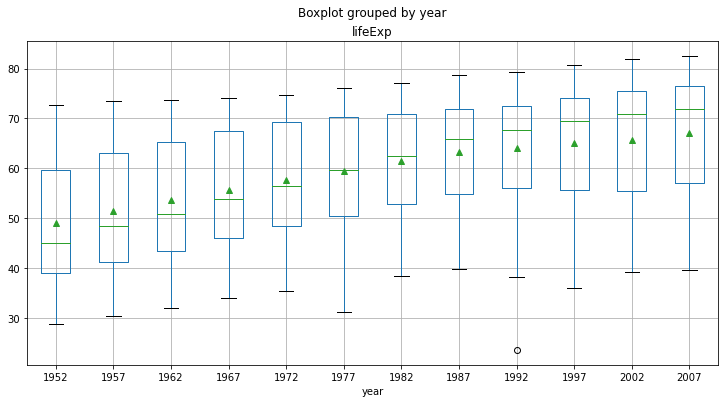

```python
fig, ax = plt.subplots(figsize=(12, 6))

gap_df.boxplot(ax=ax, column=['lifeExp'], by='year', showmeans=True)

plt.show()
```

## SPLIT-APPLY-COMBINE

Split data into groups, apply functions to summarize each group, and recombine the summarized data together again.

```python
gap_1952 = gap_df.loc[ gap_df.year == 1952 ].copy()
```

```python
gap_1952.info()
```

```
<class 'pandas.core.frame.DataFrame'>
Int64Index: 142 entries, 0 to 1692
Data columns (total 6 columns):
 #   Column     Non-Null Count  Dtype
---  ------     --------------  -----
 0   country    142 non-null    object
 1   continent  142 non-null    object
 2   year       142 non-null    int64
 3   lifeExp    142 non-null    float64
 4   pop        142 non-null    int64
 5   gdpPercap  142 non-null    float64
dtypes: float64(2), int64(2), object(2)
memory usage: 7.8+ KB
```

```python
gap_1952.year.value_counts()
```

```
1952    142
Name: year, dtype: int64
```

```python
gap_1957 = gap_df.loc[ gap_df.year == 1957 ].copy()

gap_1962 = gap_df.loc[ gap_df.year == 1962 ].copy()
```

**APPLY** functions to summarize each grouped data set.

```python
gap_1952.lifeExp.mean()
```

```
49.05761971830987
```

```python
gap_1957.lifeExp.mean()
```

```
51.507401126760534
```

```python
gap_1962.lifeExp.mean()
```

```
53.60924901408449
```

**COMBINE** the summary statistics back together.

```python
gap_lifExp_year = pd.DataFrame({'year': [1952, 1957, 1962],
                                'lifeExp': [gap_1952.lifeExp.mean(),
                                            gap_1957.lifeExp.mean(),
                                            gap_1962.lifeExp.mean()]})
```

```python
gap_lifExp_year
```

|  | year | lifeExp |
| --- | --- | --- |
| 0 | 1952 | 49.057620 |
| 1 | 1957 | 51.507401 |
| 2 | 1962 | 53.609249 |

The `.groupby()` method manages all three steps for us.

Calculate the average `lifeExp` per `year`.

```python
gap_df.groupby('year').lifeExp.mean()
```

```
year
1952    49.057620
1957    51.507401
1962    53.609249
1967    55.678290
1972    57.647386
1977    59.570157
1982    61.533197
1987    63.212613
1992    64.160338
1997    65.014676
2002    65.694923
2007    67.007423
Name: lifeExp, dtype: float64
```

```python
gap_lifExp_year
```

|  | year | lifeExp |
| --- | --- | --- |
| 0 | 1952 | 49.057620 |
| 1 | 1957 | 51.507401 |
| 2 | 1962 | 53.609249 |

We can also use string notation not just dot-notation.

```python
gap_df.groupby('year')['lifeExp'].mean()
```

```
year
1952    49.057620
1957    51.507401
1962    53.609249
1967    55.678290
1972    57.647386
1977    59.570157
1982    61.533197
1987    63.212613
1992    64.160338
1997    65.014676
2002    65.694923
2007    67.007423
Name: lifeExp, dtype: float64
```

```python
type( gap_df.groupby('year')['lifeExp'].mean() )
```

```
pandas.core.series.Series
```

```python
gap_df.groupby('year').lifeExp.describe()
```

| year | count | mean | std | min | 25% | 50% | 75% | max |
| --- | --- | --- | --- | --- | --- | --- | --- | --- |
| 1952 | 142.0 | 49.057620 | 12.225956 | 28.801 | 39.05900 | 45.1355 | 59.76500 | 72.670 |
| 1957 | 142.0 | 51.507401 | 12.231286 | 30.332 | 41.24750 | 48.3605 | 63.03675 | 73.470 |
| 1962 | 142.0 | 53.609249 | 12.097245 | 31.997 | 43.46850 | 50.8810 | 65.23450 | 73.680 |
| 1967 | 142.0 | 55.678290 | 11.718858 | 34.020 | 46.03375 | 53.8250 | 67.41950 | 74.160 |
| 1972 | 142.0 | 57.647386 | 11.381953 | 35.400 | 48.50025 | 56.5300 | 69.24750 | 74.720 |
| 1977 | 142.0 | 59.570157 | 11.227229 | 31.220 | 50.47550 | 59.6720 | 70.38250 | 76.110 |
| 1982 | 142.0 | 61.533197 | 10.770618 | 38.445 | 52.94000 | 62.4415 | 70.92125 | 77.110 |
| 1987 | 142.0 | 63.212613 | 10.556285 | 39.906 | 54.94075 | 65.8340 | 71.87725 | 78.670 |
| 1992 | 142.0 | 64.160338 | 11.227380 | 23.599 | 56.12175 | 67.7030 | 72.58250 | 79.360 |
| 1997 | 142.0 | 65.014676 | 11.559439 | 36.087 | 55.63375 | 69.3940 | 74.16975 | 80.690 |
| 2002 | 142.0 | 65.694923 | 12.279823 | 39.193 | 55.52225 | 70.8255 | 75.45925 | 82.000 |
| 2007 | 142.0 | 67.007423 | 12.073021 | 39.613 | 57.16025 | 71.9355 | 76.41325 | 82.603 |

```python
gap_df.groupby('year').lifeExp.describe().info()
```

```
<class 'pandas.core.frame.DataFrame'>
Int64Index: 12 entries, 1952 to 2007
Data columns (total 8 columns):
 #   Column  Non-Null Count  Dtype
---  ------  --------------  -----
 0   count   12 non-null     float64
 1   mean    12 non-null     float64
 2   std     12 non-null     float64
 3   min     12 non-null     float64
 4   25%     12 non-null     float64
 5   50%     12 non-null     float64
 6   75%     12 non-null     float64
 7   max     12 non-null     float64
dtypes: float64(8)
memory usage: 864.0 bytes
```

```python
gap_df.groupby('year').lifeExp.describe().index
```

```
Int64Index([1952, 1957, 1962, 1967, 1972, 1977, 1982, 1987, 1992, 1997, 2002,
            2007],
           dtype='int64', name='year')
```

```python
gap_df.groupby('year').lifeExp.describe().columns
```

```
Index(['count', 'mean', 'std', 'min', '25%', '50%', '75%', 'max'], dtype='object')
```

```python
gap_df.groupby('year').lifeExp.describe().drop(['count', 'std'], axis=1)
```

| year | mean | min | 25% | 50% | 75% | max |
| --- | --- | --- | --- | --- | --- | --- |
| 1952 | 49.057620 | 28.801 | 39.05900 | 45.1355 | 59.76500 | 72.670 |
| 1957 | 51.507401 | 30.332 | 41.24750 | 48.3605 | 63.03675 | 73.470 |
| 1962 | 53.609249 | 31.997 | 43.46850 | 50.8810 | 65.23450 | 73.680 |
| 1967 | 55.678290 | 34.020 | 46.03375 | 53.8250 | 67.41950 | 74.160 |
| 1972 | 57.647386 | 35.400 | 48.50025 | 56.5300 | 69.24750 | 74.720 |
| 1977 | 59.570157 | 31.220 | 50.47550 | 59.6720 | 70.38250 | 76.110 |
| 1982 | 61.533197 | 38.445 | 52.94000 | 62.4415 | 70.92125 | 77.110 |
| 1987 | 63.212613 | 39.906 | 54.94075 | 65.8340 | 71.87725 | 78.670 |
| 1992 | 64.160338 | 23.599 | 56.12175 | 67.7030 | 72.58250 | 79.360 |
| 1997 | 65.014676 | 36.087 | 55.63375 | 69.3940 | 74.16975 | 80.690 |
| 2002 | 65.694923 | 39.193 | 55.52225 | 70.8255 | 75.45925 | 82.000 |
| 2007 | 67.007423 | 39.613 | 57.16025 | 71.9355 | 76.41325 | 82.603 |

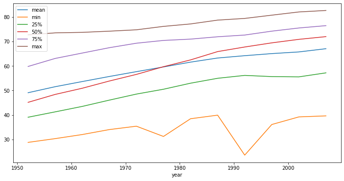

```python
fig, ax = plt.subplots(figsize=(12, 6))

gap_df.groupby('year').lifeExp.describe().drop(['count', 'std'], axis=1).plot(ax=ax)

plt.show()
```

```python
variable_to_summarize = 'lifeExp'
```

```python
gap_df.groupby('year')[variable_to_summarize].describe()
```

| year | count | mean | std | min | 25% | 50% | 75% | max |
| --- | --- | --- | --- | --- | --- | --- | --- | --- |
| 1952 | 142.0 | 49.057620 | 12.225956 | 28.801 | 39.05900 | 45.1355 | 59.76500 | 72.670 |
| 1957 | 142.0 | 51.507401 | 12.231286 | 30.332 | 41.24750 | 48.3605 | 63.03675 | 73.470 |
| 1962 | 142.0 | 53.609249 | 12.097245 | 31.997 | 43.46850 | 50.8810 | 65.23450 | 73.680 |
| 1967 | 142.0 | 55.678290 | 11.718858 | 34.020 | 46.03375 | 53.8250 | 67.41950 | 74.160 |
| 1972 | 142.0 | 57.647386 | 11.381953 | 35.400 | 48.50025 | 56.5300 | 69.24750 | 74.720 |
| 1977 | 142.0 | 59.570157 | 11.227229 | 31.220 | 50.47550 | 59.6720 | 70.38250 | 76.110 |
| 1982 | 142.0 | 61.533197 | 10.770618 | 38.445 | 52.94000 | 62.4415 | 70.92125 | 77.110 |
| 1987 | 142.0 | 63.212613 | 10.556285 | 39.906 | 54.94075 | 65.8340 | 71.87725 | 78.670 |
| 1992 | 142.0 | 64.160338 | 11.227380 | 23.599 | 56.12175 | 67.7030 | 72.58250 | 79.360 |
| 1997 | 142.0 | 65.014676 | 11.559439 | 36.087 | 55.63375 | 69.3940 | 74.16975 | 80.690 |
| 2002 | 142.0 | 65.694923 | 12.279823 | 39.193 | 55.52225 | 70.8255 | 75.45925 | 82.000 |
| 2007 | 142.0 | 67.007423 | 12.073021 | 39.613 | 57.16025 | 71.9355 | 76.41325 | 82.603 |

If we apply `.describe()` to the grouped data set...

```python
gap_df.groupby('year').describe()
```

| year | lifeExp count | lifeExp mean | lifeExp std | lifeExp min | lifeExp 25% | lifeExp 50% | lifeExp 75% | lifeExp max | pop count | pop mean | pop ... | pop 75% | pop max | gdpPercap count | gdpPercap mean | gdpPercap std | gdpPercap min | gdpPercap 25% | gdpPercap 50% | gdpPercap 75% | gdpPercap max |
| --- | --- | --- | --- | --- | --- | --- | --- | --- | --- | --- | --- | --- | --- | --- | --- | --- | --- | --- | --- | --- | --- |
| 1952 | 142.0 | 49.057620 | 12.225956 | 28.801 | 39.05900 | 45.1355 | 59.76500 | 72.670 | 142.0 | 1.695040e+07 | ... | 9168197.75 | 5.562635e+08 | 142.0 | 3725.276046 | 9321.064786 | 298.846212 | 864.752389 | 1968.528344 | 3913.492777 | 108382.35290 |
| 1957 | 142.0 | 51.507401 | 12.231286 | 30.332 | 41.24750 | 48.3605 | 63.03675 | 73.470 | 142.0 | 1.876341e+07 | ... | 9817598.00 | 6.374080e+08 | 142.0 | 4299.408345 | 9869.662202 | 335.997115 | 930.540819 | 2173.220291 | 4876.356362 | 113523.13290 |
| 1962 | 142.0 | 53.609249 | 12.097245 | 31.997 | 43.46850 | 50.8810 | 65.23450 | 73.680 | 142.0 | 2.042101e+07 | ... | 10980084.50 | 6.657700e+08 | 142.0 | 4725.812342 | 8667.362525 | 355.203227 | 1059.149171 | 2335.439533 | 5709.381428 | 95458.11176 |
| 1967 | 142.0 | 55.678290 | 11.718858 | 34.020 | 46.03375 | 53.8250 | 67.41950 | 74.160 | 142.0 | 2.265830e+07 | ... | 12614584.75 | 7.545500e+08 | 142.0 | 5483.653047 | 8095.315431 | 349.000000 | 1151.245103 | 2678.334740 | 7075.932943 | 80894.88326 |
| 1972 | 142.0 | 57.647386 | 11.381953 | 35.400 | 48.50025 | 56.5300 | 69.24750 | 74.720 | 142.0 | 2.518998e+07 | ... | 14679199.50 | 8.620300e+08 | 142.0 | 6770.082815 | 10614.383403 | 357.000000 | 1257.193853 | 3339.129407 | 9508.839304 | 109347.86700 |
| 1977 | 142.0 | 59.570157 | 11.227229 | 31.220 | 50.47550 | 59.6720 | 70.38250 | 76.110 | 142.0 | 2.767638e+07 | ... | 16670227.00 | 9.434550e+08 | 142.0 | 7313.166421 | 8362.489150 | 371.000000 | 1357.257252 | 3798.609244 | 11204.102423 | 59265.47714 |
| 1982 | 142.0 | 61.533197 | 10.770618 | 38.445 | 52.94000 | 62.4415 | 70.92125 | 77.110 | 142.0 | 3.020730e+07 | ... | 18407324.75 | 1.000281e+09 | 142.0 | 7518.901673 | 7733.845006 | 424.000000 | 1363.338985 | 4216.228428 | 12347.953722 | 33693.17525 |
| 1987 | 142.0 | 63.212613 | 10.556285 | 39.906 | 54.94075 | 65.8340 | 71.87725 | 78.670 | 142.0 | 3.303857e+07 | ... | 20947542.50 | 1.084035e+09 | 142.0 | 7900.920218 | 8288.281304 | 385.000000 | 1327.469823 | 4280.300366 | 11994.052795 | 31540.97480 |
| 1992 | 142.0 | 64.160338 | 11.227380 | 23.599 | 56.12175 | 67.7030 | 72.58250 | 79.360 | 142.0 | 3.599092e+07 | ... | 22705382.50 | 1.164970e+09 | 142.0 | 8158.608521 | 9031.846080 | 347.000000 | 1270.660958 | 4386.085502 | 10684.351870 | 34932.91959 |
| 1997 | 142.0 | 65.014676 | 11.559439 | 36.087 | 55.63375 | 69.3940 | 74.16975 | 80.690 | 142.0 | 3.883947e+07 | ... | 24311369.75 | 1.230075e+09 | 142.0 | 9090.175363 | 10171.493263 | 312.188423 | 1366.837958 | 4781.825478 | 12022.867188 | 41283.16433 |
| 2002 | 142.0 | 65.694923 | 12.279823 | 39.193 | 55.52225 | 70.8255 | 75.45925 | 82.000 | 142.0 | 4.145759e+07 | ... | 26545556.25 | 1.280400e+09 | 142.0 | 9917.848365 | 11154.114865 | 241.165876 | 1409.567264 | 5319.804524 | 13359.512258 | 44683.97525 |
| 2007 | 142.0 | 67.007423 | 12.073021 | 39.613 | 57.16025 | 71.9355 | 76.41325 | 82.603 | 142.0 | 4.402122e+07 | ... | 31210041.75 | 1.318683e+09 | 142.0 | 11680.071820 | 12859.937337 | 277.551859 | 1624.842248 | 6124.371108 | 18008.835640 | 49357.19017 |

12 rows × 24 columns

```python
gap_df.groupby('year').describe().columns
```

```
MultiIndex([(  'lifeExp', 'count'),
            (  'lifeExp',  'mean'),
            (  'lifeExp',   'std'),
            (  'lifeExp',   'min'),
            (  'lifeExp',   '25%'),
            (  'lifeExp',   '50%'),
            (  'lifeExp',   '75%'),
            (  'lifeExp',   'max'),
            (      'pop', 'count'),
            (      'pop',  'mean'),
            (      'pop',   'std'),
            (      'pop',   'min'),
            (      'pop',   '25%'),
            (      'pop',   '50%'),
            (      'pop',   '75%'),
            (      'pop',   'max'),
            ('gdpPercap', 'count'),
            ('gdpPercap',  'mean'),
            ('gdpPercap',   'std'),
            ('gdpPercap',   'min'),
            ('gdpPercap',   '25%'),
            ('gdpPercap',   '50%'),
            ('gdpPercap',   '75%'),
            ('gdpPercap',   'max')],
           )
```

### Apply custom functions to group

Create out own function which calculates the IQR.

```python
def my_iqr(values):
    q25 = np.percentile(values, q=25)
    q75 = np.percentile(values, q=75)

    return q75 - q25
```

We need to combine `.groupby()` with the `.aggregate()` or the `.agg()` function.

```python
gap_df.groupby('year').lifeExp.aggregate(my_iqr)
```

```
year
1952    20.70600
1957    21.78925
1962    21.76600
1967    21.38575
1972    20.74725
1977    19.90700
1982    17.98125
1987    16.93650
1992    16.46075
1997    18.53600
2002    19.93700
2007    19.25300
Name: lifeExp, dtype: float64
```

```python
gap_year_summary = gap_df.groupby('year').lifeExp.describe()
```

```python
gap_year_summary
```

| year | count | mean | std | min | 25% | 50% | 75% | max |
| --- | --- | --- | --- | --- | --- | --- | --- | --- |
| 1952 | 142.0 | 49.057620 | 12.225956 | 28.801 | 39.05900 | 45.1355 | 59.76500 | 72.670 |
| 1957 | 142.0 | 51.507401 | 12.231286 | 30.332 | 41.24750 | 48.3605 | 63.03675 | 73.470 |
| 1962 | 142.0 | 53.609249 | 12.097245 | 31.997 | 43.46850 | 50.8810 | 65.23450 | 73.680 |
| 1967 | 142.0 | 55.678290 | 11.718858 | 34.020 | 46.03375 | 53.8250 | 67.41950 | 74.160 |
| 1972 | 142.0 | 57.647386 | 11.381953 | 35.400 | 48.50025 | 56.5300 | 69.24750 | 74.720 |
| 1977 | 142.0 | 59.570157 | 11.227229 | 31.220 | 50.47550 | 59.6720 | 70.38250 | 76.110 |
| 1982 | 142.0 | 61.533197 | 10.770618 | 38.445 | 52.94000 | 62.4415 | 70.92125 | 77.110 |
| 1987 | 142.0 | 63.212613 | 10.556285 | 39.906 | 54.94075 | 65.8340 | 71.87725 | 78.670 |
| 1992 | 142.0 | 64.160338 | 11.227380 | 23.599 | 56.12175 | 67.7030 | 72.58250 | 79.360 |
| 1997 | 142.0 | 65.014676 | 11.559439 | 36.087 | 55.63375 | 69.3940 | 74.16975 | 80.690 |
| 2002 | 142.0 | 65.694923 | 12.279823 | 39.193 | 55.52225 | 70.8255 | 75.45925 | 82.000 |
| 2007 | 142.0 | 67.007423 | 12.073021 | 39.613 | 57.16025 | 71.9355 | 76.41325 | 82.603 |

```python
gap_year_summary['IQR'] = gap_year_summary['75%'] - gap_year_summary['25%']
```

```python
gap_year_summary
```

| year | count | mean | std | min | 25% | 50% | 75% | max | IQR |
| --- | --- | --- | --- | --- | --- | --- | --- | --- | --- |
| 1952 | 142.0 | 49.057620 | 12.225956 | 28.801 | 39.05900 | 45.1355 | 59.76500 | 72.670 | 20.70600 |
| 1957 | 142.0 | 51.507401 | 12.231286 | 30.332 | 41.24750 | 48.3605 | 63.03675 | 73.470 | 21.78925 |
| 1962 | 142.0 | 53.609249 | 12.097245 | 31.997 | 43.46850 | 50.8810 | 65.23450 | 73.680 | 21.76600 |
| 1967 | 142.0 | 55.678290 | 11.718858 | 34.020 | 46.03375 | 53.8250 | 67.41950 | 74.160 | 21.38575 |
| 1972 | 142.0 | 57.647386 | 11.381953 | 35.400 | 48.50025 | 56.5300 | 69.24750 | 74.720 | 20.74725 |
| 1977 | 142.0 | 59.570157 | 11.227229 | 31.220 | 50.47550 | 59.6720 | 70.38250 | 76.110 | 19.90700 |
| 1982 | 142.0 | 61.533197 | 10.770618 | 38.445 | 52.94000 | 62.4415 | 70.92125 | 77.110 | 17.98125 |
| 1987 | 142.0 | 63.212613 | 10.556285 | 39.906 | 54.94075 | 65.8340 | 71.87725 | 78.670 | 16.93650 |
| 1992 | 142.0 | 64.160338 | 11.227380 | 23.599 | 56.12175 | 67.7030 | 72.58250 | 79.360 | 16.46075 |
| 1997 | 142.0 | 65.014676 | 11.559439 | 36.087 | 55.63375 | 69.3940 | 74.16975 | 80.690 | 18.53600 |
| 2002 | 142.0 | 65.694923 | 12.279823 | 39.193 | 55.52225 | 70.8255 | 75.45925 | 82.000 | 19.93700 |
| 2007 | 142.0 | 67.007423 | 12.073021 | 39.613 | 57.16025 | 71.9355 | 76.41325 | 82.603 | 19.25300 |

```python
gap_year_summary.IQR
```

```
year
1952    20.70600
1957    21.78925
1962    21.76600
1967    21.38575
1972    20.74725
1977    19.90700
1982    17.98125
1987    16.93650
1992    16.46075
1997    18.53600
2002    19.93700
2007    19.25300
Name: IQR, dtype: float64
```

```python
gap_df.groupby('year').lifeExp.aggregate(my_iqr)
```

```
year
1952    20.70600
1957    21.78925
1962    21.76600
1967    21.38575
1972    20.74725
1977    19.90700
1982    17.98125
1987    16.93650
1992    16.46075
1997    18.53600
2002    19.93700
2007    19.25300
Name: lifeExp, dtype: float64
```

```python
gap_df.groupby('year').lifeExp.mean()
```

```
year
1952    49.057620
1957    51.507401
1962    53.609249
1967    55.678290
1972    57.647386
1977    59.570157
1982    61.533197
1987    63.212613
1992    64.160338
1997    65.014676
2002    65.694923
2007    67.007423
Name: lifeExp, dtype: float64
```

```python
gap_df.groupby('year').lifeExp.sem()
```

```
year
1952    1.025979
1957    1.026427
1962    1.015178
1967    0.983425
1972    0.955152
1977    0.942168
1982    0.903850
1987    0.885864
1992    0.942181
1997    0.970047
2002    1.030500
2007    1.013145
Name: lifeExp, dtype: float64
```

Apply multiple functions per group.

```python
gap_df.groupby('year').lifeExp.aggregate( [ 'mean', 'sem' ])
```

| year | mean | sem |
| --- | --- | --- |
| 1952 | 49.057620 | 1.025979 |
| 1957 | 51.507401 | 1.026427 |
| 1962 | 53.609249 | 1.015178 |
| 1967 | 55.678290 | 0.983425 |
| 1972 | 57.647386 | 0.955152 |
| 1977 | 59.570157 | 0.942168 |
| 1982 | 61.533197 | 0.903850 |
| 1987 | 63.212613 | 0.885864 |
| 1992 | 64.160338 | 0.942181 |
| 1997 | 65.014676 | 0.970047 |
| 2002 | 65.694923 | 1.030500 |
| 2007 | 67.007423 | 1.013145 |

```python
gap_df.groupby('year').lifeExp.aggregate( [ np.min, np.max, 'mean', 'sem' ])
```

| year | amin | amax | mean | sem |
| --- | --- | --- | --- | --- |
| 1952 | 28.801 | 72.670 | 49.057620 | 1.025979 |
| 1957 | 30.332 | 73.470 | 51.507401 | 1.026427 |
| 1962 | 31.997 | 73.680 | 53.609249 | 1.015178 |
| 1967 | 34.020 | 74.160 | 55.678290 | 0.983425 |
| 1972 | 35.400 | 74.720 | 57.647386 | 0.955152 |
| 1977 | 31.220 | 76.110 | 59.570157 | 0.942168 |
| 1982 | 38.445 | 77.110 | 61.533197 | 0.903850 |
| 1987 | 39.906 | 78.670 | 63.212613 | 0.885864 |
| 1992 | 23.599 | 79.360 | 64.160338 | 0.942181 |
| 1997 | 36.087 | 80.690 | 65.014676 | 0.970047 |
| 2002 | 39.193 | 82.000 | 65.694923 | 1.030500 |
| 2007 | 39.613 | 82.603 | 67.007423 | 1.013145 |

```python
gap_df.groupby('year').lifeExp.aggregate( [ np.min, np.max, my_iqr, 'mean', 'sem' ])
```

| year | amin | amax | my_iqr | mean | sem |
| --- | --- | --- | --- | --- | --- |
| 1952 | 28.801 | 72.670 | 20.70600 | 49.057620 | 1.025979 |
| 1957 | 30.332 | 73.470 | 21.78925 | 51.507401 | 1.026427 |
| 1962 | 31.997 | 73.680 | 21.76600 | 53.609249 | 1.015178 |
| 1967 | 34.020 | 74.160 | 21.38575 | 55.678290 | 0.983425 |
| 1972 | 35.400 | 74.720 | 20.74725 | 57.647386 | 0.955152 |
| 1977 | 31.220 | 76.110 | 19.90700 | 59.570157 | 0.942168 |
| 1982 | 38.445 | 77.110 | 17.98125 | 61.533197 | 0.903850 |
| 1987 | 39.906 | 78.670 | 16.93650 | 63.212613 | 0.885864 |
| 1992 | 23.599 | 79.360 | 16.46075 | 64.160338 | 0.942181 |
| 1997 | 36.087 | 80.690 | 18.53600 | 65.014676 | 0.970047 |
| 2002 | 39.193 | 82.000 | 19.93700 | 65.694923 | 1.030500 |
| 2007 | 39.613 | 82.603 | 19.25300 | 67.007423 | 1.013145 |

We can rename columns after performing the groupby and aggregation.

```python
gap_df.groupby('year')['lifeExp'].\
aggregate(['mean', 'min', 'max', 'sem']).\
rename(columns={'mean': 'avg_lifeExp',
                'min': 'min_lifeExp',
                'max': 'max_lifeExp',
                'sem': 'se_avg'})
```

| year | avg_lifeExp | min_lifeExp | max_lifeExp | se_avg |
| --- | --- | --- | --- | --- |
| 1952 | 49.057620 | 28.801 | 72.670 | 1.025979 |
| 1957 | 51.507401 | 30.332 | 73.470 | 1.026427 |
| 1962 | 53.609249 | 31.997 | 73.680 | 1.015178 |
| 1967 | 55.678290 | 34.020 | 74.160 | 0.983425 |
| 1972 | 57.647386 | 35.400 | 74.720 | 0.955152 |
| 1977 | 59.570157 | 31.220 | 76.110 | 0.942168 |
| 1982 | 61.533197 | 38.445 | 77.110 | 0.903850 |
| 1987 | 63.212613 | 39.906 | 78.670 | 0.885864 |
| 1992 | 64.160338 | 23.599 | 79.360 | 0.942181 |
| 1997 | 65.014676 | 36.087 | 80.690 | 0.970047 |
| 2002 | 65.694923 | 39.193 | 82.000 | 1.030500 |
| 2007 | 67.007423 | 39.613 | 82.603 | 1.013145 |

We can reset index to bring the grouping variable back into the DataFrame.

```python
gap_df.groupby('year')['lifeExp'].\
aggregate(['mean', 'min', 'max', 'sem']).\
rename(columns={'mean': 'avg_lifeExp',
                'min': 'min_lifeExp',
                'max': 'max_lifeExp',
                'sem': 'se_avg'}).\
reset_index()
```

|  | year | avg_lifeExp | min_lifeExp | max_lifeExp | se_avg |
| --- | --- | --- | --- | --- | --- |
| 0 | 1952 | 49.057620 | 28.801 | 72.670 | 1.025979 |
| 1 | 1957 | 51.507401 | 30.332 | 73.470 | 1.026427 |
| 2 | 1962 | 53.609249 | 31.997 | 73.680 | 1.015178 |
| 3 | 1967 | 55.678290 | 34.020 | 74.160 | 0.983425 |
| 4 | 1972 | 57.647386 | 35.400 | 74.720 | 0.955152 |
| 5 | 1977 | 59.570157 | 31.220 | 76.110 | 0.942168 |
| 6 | 1982 | 61.533197 | 38.445 | 77.110 | 0.903850 |
| 7 | 1987 | 63.212613 | 39.906 | 78.670 | 0.885864 |
| 8 | 1992 | 64.160338 | 23.599 | 79.360 | 0.942181 |
| 9 | 1997 | 65.014676 | 36.087 | 80.690 | 0.970047 |
| 10 | 2002 | 65.694923 | 39.193 | 82.000 | 1.030500 |
| 11 | 2007 | 67.007423 | 39.613 | 82.603 | 1.013145 |

To compare the index results.

```python
gap_df.groupby('year')['lifeExp'].\
aggregate(['mean', 'min', 'max', 'sem']).\
rename(columns={'mean': 'avg_lifeExp',
                'min': 'min_lifeExp',
                'max': 'max_lifeExp',
                'sem': 'se_avg'}).\
index
```

```
Int64Index([1952, 1957, 1962, 1967, 1972, 1977, 1982, 1987, 1992, 1997, 2002,
            2007],
           dtype='int64', name='year')
```

```python
gap_df.groupby('year')['lifeExp'].\
aggregate(['mean', 'min', 'max', 'sem']).\
rename(columns={'mean': 'avg_lifeExp',
                'min': 'min_lifeExp',
                'max': 'max_lifeExp',
                'sem': 'se_avg'}).\
reset_index().\
index
```

```
RangeIndex(start=0, stop=12, step=1)
```

### Group by multiple columns

```python
gap_df.groupby(['year', 'continent']).size()
```

```
year  continent
1952  Africa       52
      Americas     25
      Asia         33
      Europe       30
      Oceania       2
1957  Africa       52
      Americas     25
      Asia         33
      Europe       30
      Oceania       2
1962  Africa       52
      Americas     25
      Asia         33
      Europe       30
      Oceania       2
1967  Africa       52
      Americas     25
      Asia         33
      Europe       30
      Oceania       2
1972  Africa       52
      Americas     25
      Asia         33
      Europe       30
      Oceania       2
1977  Africa       52
      Americas     25
      Asia         33
      Europe       30
      Oceania       2
1982  Africa       52
      Americas     25
      Asia         33
      Europe       30
      Oceania       2
1987  Africa       52
      Americas     25
      Asia         33
      Europe       30
      Oceania       2
1992  Africa       52
      Americas     25
      Asia         33
      Europe       30
      Oceania       2
1997  Africa       52
      Americas     25
      Asia         33
      Europe       30
      Oceania       2
2002  Africa       52
      Americas     25
      Asia         33
      Europe       30
      Oceania       2
2007  Africa       52
      Americas     25
      Asia         33
      Europe       30
      Oceania       2
dtype: int64
```

THe index is a multi-index with the hierarchical structuring of the rows.

```python
gap_df.groupby(['year', 'continent']).lifeExp.mean()
```

```
year  continent
1952  Africa       39.135500
      Americas     53.279840
      Asia         46.314394
      Europe       64.408500
      Oceania      69.255000
1957  Africa       41.266346
      Americas     55.960280
      Asia         49.318544
      Europe       66.703067
      Oceania      70.295000
1962  Africa       43.319442
      Americas     58.398760
      Asia         51.563223
      Europe       68.539233
      Oceania      71.085000
1967  Africa       45.334538
      Americas     60.410920
      Asia         54.663640
      Europe       69.737600
      Oceania      71.310000
1972  Africa       47.450942
      Americas     62.394920
      Asia         57.319269
      Europe       70.775033
      Oceania      71.910000
1977  Africa       49.580423
      Americas     64.391560
      Asia         59.610556
      Europe       71.937767
      Oceania      72.855000
1982  Africa       51.592865
      Americas     66.228840
      Asia         62.617939
      Europe       72.806400
      Oceania      74.290000
1987  Africa       53.344788
      Americas     68.090720
      Asia         64.851182
      Europe       73.642167
      Oceania      75.320000
1992  Africa       53.629577
      Americas     69.568360
      Asia         66.537212
      Europe       74.440100
      Oceania      76.945000
1997  Africa       53.598269
      Americas     71.150480
      Asia         68.020515
      Europe       75.505167
      Oceania      78.190000
2002  Africa       53.325231
      Americas     72.422040
      Asia         69.233879
      Europe       76.700600
      Oceania      79.740000
2007  Africa       54.806038
      Americas     73.608120
      Asia         70.728485
      Europe       77.648600
      Oceania      80.719500
Name: lifeExp, dtype: float64
```

If we don't specify the column the method is applied to all columns.

```python
gap_df.groupby(['year', 'continent']).mean()
```

| year | continent | lifeExp | pop | gdpPercap |
| --- | --- | --- | --- | --- |
| 1952 | Africa | 39.135500 | 4.570010e+06 | 1252.572466 |
|  | Americas | 53.279840 | 1.380610e+07 | 4079.062552 |
|  | Asia | 46.314394 | 4.228356e+07 | 5195.484004 |
|  | Europe | 64.408500 | 1.393736e+07 | 5661.057435 |
|  | Oceania | 69.255000 | 5.343003e+06 | 10298.085650 |
| 1957 | Africa | 41.266346 | 5.093033e+06 | 1385.236062 |
|  | Americas | 55.960280 | 1.547816e+07 | 4616.043733 |
|  | Asia | 49.318544 | 4.735699e+07 | 5787.732940 |
|  | Europe | 66.703067 | 1.459635e+07 | 6963.012816 |
|  | Oceania | 70.295000 | 5.970988e+06 | 11598.522455 |
| 1962 | Africa | 43.319442 | 5.702247e+06 | 1598.078825 |
|  | Americas | 58.398760 | 1.733081e+07 | 4901.541870 |
|  | Asia | 51.563223 | 5.140476e+07 | 5729.369625 |
|  | Europe | 68.539233 | 1.534517e+07 | 8365.486814 |
|  | Oceania | 71.085000 | 6.641759e+06 | 12696.452430 |
| 1967 | Africa | 45.334538 | 6.447875e+06 | 2050.363801 |
|  | Americas | 60.410920 | 1.922986e+07 | 5668.253496 |
|  | Asia | 54.663640 | 5.774736e+07 | 5971.173374 |
|  | Europe | 69.737600 | 1.603930e+07 | 10143.823757 |
|  | Oceania | 71.310000 | 7.300207e+06 | 14495.021790 |
| 1972 | Africa | 47.450942 | 7.305376e+06 | 2339.615674 |
|  | Americas | 62.394920 | 2.117537e+07 | 6491.334139 |
|  | Asia | 57.319269 | 6.518098e+07 | 8187.468699 |
|  | Europe | 70.775033 | 1.668784e+07 | 12479.575246 |
|  | Oceania | 71.910000 | 8.053050e+06 | 16417.333380 |
| 1977 | Africa | 49.580423 | 8.328097e+06 | 2585.938508 |
|  | Americas | 64.391560 | 2.312271e+07 | 7352.007126 |
|  | Asia | 59.610556 | 7.225799e+07 | 7791.314020 |
|  | Europe | 71.937767 | 1.723882e+07 | 14283.979110 |
|  | Oceania | 72.855000 | 8.619500e+06 | 17283.957605 |
| 1982 | Africa | 51.592865 | 9.602857e+06 | 2481.592960 |
|  | Americas | 66.228840 | 2.521164e+07 | 7506.737088 |
|  | Asia | 62.617939 | 7.909502e+07 | 7434.135157 |
|  | Europe | 72.806400 | 1.770890e+07 | 15617.896551 |
|  | Oceania | 74.290000 | 9.197425e+06 | 18554.709840 |
| 1987 | Africa | 53.344788 | 1.105450e+07 | 2282.668991 |
|  | Americas | 68.090720 | 2.731016e+07 | 7793.400261 |
|  | Asia | 64.851182 | 8.700669e+07 | 7608.226508 |
|  | Europe | 73.642167 | 1.810314e+07 | 17214.310727 |
|  | Oceania | 75.320000 | 9.787208e+06 | 20448.040160 |
| 1992 | Africa | 53.629577 | 1.267464e+07 | 2281.810333 |
|  | Americas | 69.568360 | 2.957096e+07 | 8044.934406 |
|  | Asia | 66.537212 | 9.494825e+07 | 8639.690248 |
|  | Europe | 74.440100 | 1.860476e+07 | 17061.568084 |
|  | Oceania | 76.945000 | 1.045983e+07 | 20894.045885 |
| 1997 | Africa | 53.598269 | 1.430448e+07 | 2378.759555 |
|  | Americas | 71.150480 | 3.187602e+07 | 8889.300863 |
|  | Asia | 68.020515 | 1.025238e+08 | 9834.093295 |
|  | Europe | 75.505167 | 1.896480e+07 | 19076.781802 |
|  | Oceania | 78.190000 | 1.112072e+07 | 24024.175170 |
| 2002 | Africa | 53.325231 | 1.603315e+07 | 2599.385159 |
|  | Americas | 72.422040 | 3.399091e+07 | 9287.677107 |
|  | Asia | 69.233879 | 1.091455e+08 | 10174.090397 |
|  | Europe | 76.700600 | 1.927413e+07 | 21711.732422 |
|  | Oceania | 79.740000 | 1.172741e+07 | 26938.778040 |
| 2007 | Africa | 54.806038 | 1.787576e+07 | 3089.032605 |
|  | Americas | 73.608120 | 3.595485e+07 | 11003.031625 |
|  | Asia | 70.728485 | 1.155138e+08 | 12473.026870 |
|  | Europe | 77.648600 | 1.953662e+07 | 25054.481636 |
|  | Oceania | 80.719500 | 1.227497e+07 | 29810.188275 |

Reset to remove the multi-index.

```python
gap_df.groupby(['year', 'continent']).mean().reset_index()
```

|  | year | continent | lifeExp | pop | gdpPercap |
| --- | --- | --- | --- | --- | --- |
| 0 | 1952 | Africa | 39.135500 | 4.570010e+06 | 1252.572466 |
| 1 | 1952 | Americas | 53.279840 | 1.380610e+07 | 4079.062552 |
| 2 | 1952 | Asia | 46.314394 | 4.228356e+07 | 5195.484004 |
| 3 | 1952 | Europe | 64.408500 | 1.393736e+07 | 5661.057435 |
| 4 | 1952 | Oceania | 69.255000 | 5.343003e+06 | 10298.085650 |
| 5 | 1957 | Africa | 41.266346 | 5.093033e+06 | 1385.236062 |
| 6 | 1957 | Americas | 55.960280 | 1.547816e+07 | 4616.043733 |
| 7 | 1957 | Asia | 49.318544 | 4.735699e+07 | 5787.732940 |
| 8 | 1957 | Europe | 66.703067 | 1.459635e+07 | 6963.012816 |
| 9 | 1957 | Oceania | 70.295000 | 5.970988e+06 | 11598.522455 |
| 10 | 1962 | Africa | 43.319442 | 5.702247e+06 | 1598.078825 |
| 11 | 1962 | Americas | 58.398760 | 1.733081e+07 | 4901.541870 |
| 12 | 1962 | Asia | 51.563223 | 5.140476e+07 | 5729.369625 |
| 13 | 1962 | Europe | 68.539233 | 1.534517e+07 | 8365.486814 |
| 14 | 1962 | Oceania | 71.085000 | 6.641759e+06 | 12696.452430 |
| 15 | 1967 | Africa | 45.334538 | 6.447875e+06 | 2050.363801 |
| 16 | 1967 | Americas | 60.410920 | 1.922986e+07 | 5668.253496 |
| 17 | 1967 | Asia | 54.663640 | 5.774736e+07 | 5971.173374 |
| 18 | 1967 | Europe | 69.737600 | 1.603930e+07 | 10143.823757 |
| 19 | 1967 | Oceania | 71.310000 | 7.300207e+06 | 14495.021790 |
| 20 | 1972 | Africa | 47.450942 | 7.305376e+06 | 2339.615674 |
| 21 | 1972 | Americas | 62.394920 | 2.117537e+07 | 6491.334139 |
| 22 | 1972 | Asia | 57.319269 | 6.518098e+07 | 8187.468699 |
| 23 | 1972 | Europe | 70.775033 | 1.668784e+07 | 12479.575246 |
| 24 | 1972 | Oceania | 71.910000 | 8.053050e+06 | 16417.333380 |
| 25 | 1977 | Africa | 49.580423 | 8.328097e+06 | 2585.938508 |
| 26 | 1977 | Americas | 64.391560 | 2.312271e+07 | 7352.007126 |
| 27 | 1977 | Asia | 59.610556 | 7.225799e+07 | 7791.314020 |
| 28 | 1977 | Europe | 71.937767 | 1.723882e+07 | 14283.979110 |
| 29 | 1977 | Oceania | 72.855000 | 8.619500e+06 | 17283.957605 |
| 30 | 1982 | Africa | 51.592865 | 9.602857e+06 | 2481.592960 |
| 31 | 1982 | Americas | 66.228840 | 2.521164e+07 | 7506.737088 |
| 32 | 1982 | Asia | 62.617939 | 7.909502e+07 | 7434.135157 |
| 33 | 1982 | Europe | 72.806400 | 1.770890e+07 | 15617.896551 |
| 34 | 1982 | Oceania | 74.290000 | 9.197425e+06 | 18554.709840 |
| 35 | 1987 | Africa | 53.344788 | 1.105450e+07 | 2282.668991 |
| 36 | 1987 | Americas | 68.090720 | 2.731016e+07 | 7793.400261 |
| 37 | 1987 | Asia | 64.851182 | 8.700669e+07 | 7608.226508 |
| 38 | 1987 | Europe | 73.642167 | 1.810314e+07 | 17214.310727 |
| 39 | 1987 | Oceania | 75.320000 | 9.787208e+06 | 20448.040160 |
| 40 | 1992 | Africa | 53.629577 | 1.267464e+07 | 2281.810333 |
| 41 | 1992 | Americas | 69.568360 | 2.957096e+07 | 8044.934406 |
| 42 | 1992 | Asia | 66.537212 | 9.494825e+07 | 8639.690248 |
| 43 | 1992 | Europe | 74.440100 | 1.860476e+07 | 17061.568084 |
| 44 | 1992 | Oceania | 76.945000 | 1.045983e+07 | 20894.045885 |
| 45 | 1997 | Africa | 53.598269 | 1.430448e+07 | 2378.759555 |
| 46 | 1997 | Americas | 71.150480 | 3.187602e+07 | 8889.300863 |
| 47 | 1997 | Asia | 68.020515 | 1.025238e+08 | 9834.093295 |
| 48 | 1997 | Europe | 75.505167 | 1.896480e+07 | 19076.781802 |
| 49 | 1997 | Oceania | 78.190000 | 1.112072e+07 | 24024.175170 |
| 50 | 2002 | Africa | 53.325231 | 1.603315e+07 | 2599.385159 |
| 51 | 2002 | Americas | 72.422040 | 3.399091e+07 | 9287.677107 |
| 52 | 2002 | Asia | 69.233879 | 1.091455e+08 | 10174.090397 |
| 53 | 2002 | Europe | 76.700600 | 1.927413e+07 | 21711.732422 |
| 54 | 2002 | Oceania | 79.740000 | 1.172741e+07 | 26938.778040 |
| 55 | 2007 | Africa | 54.806038 | 1.787576e+07 | 3089.032605 |
| 56 | 2007 | Americas | 73.608120 | 3.595485e+07 | 11003.031625 |
| 57 | 2007 | Asia | 70.728485 | 1.155138e+08 | 12473.026870 |
| 58 | 2007 | Europe | 77.648600 | 1.953662e+07 | 25054.481636 |
| 59 | 2007 | Oceania | 80.719500 | 1.227497e+07 | 29810.188275 |

### Apply a specific function to specific columns

Use the `pd.NamedAgg()` function to control this behavior.

```python
gap_df.groupby(['year', 'continent']).\
aggregate(lifeExp_avg = pd.NamedAgg(column='lifeExp', aggfunc='mean'),
          lifeExp_sem = pd.NamedAgg(column='lifeExp', aggfunc='sem'),
          num_countries = pd.NamedAgg(column='country', aggfunc='nunique'),
          gdpPercap_avg = pd.NamedAgg(column='gdpPercap', aggfunc=np.mean),
          gdpPercap_iqr = pd.NamedAgg(column='gdpPercap', aggfunc=my_iqr))
```

| year | continent | lifeExp_avg | lifeExp_sem | num_countries | gdpPercap_avg | gdpPercap_iqr |
| --- | --- | --- | --- | --- | --- | --- |
| 1952 | Africa | 39.135500 | 0.714396 | 52 | 1252.572466 | 919.896091 |
|  | Americas | 53.279840 | 1.865216 | 25 | 4079.062552 | 1511.741020 |
|  | Asia | 46.314394 | 1.617486 | 33 | 5195.484004 | 2285.644347 |
|  | Europe | 64.408500 | 1.161371 | 30 | 5661.057435 | 3995.662513 |
|  | Oceania | 69.255000 | 0.135000 | 2 | 10298.085650 | 258.490010 |
| 1957 | Africa | 41.266346 | 0.779371 | 52 | 1385.236062 | 966.086087 |
|  | Americas | 55.960280 | 1.806638 | 25 | 4616.043733 | 2269.159792 |
|  | Asia | 49.318544 | 1.677313 | 33 | 5787.732940 | 2496.680228 |
|  | Europe | 66.703067 | 0.966877 | 30 | 6963.012816 | 5202.346505 |
|  | Oceania | 70.295000 | 0.035000 | 2 | 11598.522455 | 648.872865 |
| 1962 | Africa | 43.319442 | 0.814766 | 52 | 1598.078825 | 1028.890201 |
|  | Americas | 58.398760 | 1.700709 | 25 | 4901.541870 | 2430.391464 |
|  | Asia | 51.563223 | 1.709553 | 33 | 5729.369625 | 3361.706601 |
|  | Europe | 68.539233 | 0.785525 | 30 | 8365.486814 | 5557.548736 |
|  | Oceania | 71.085000 | 0.155000 | 2 | 12696.452430 | 479.225570 |
| 1967 | Africa | 45.334538 | 0.843515 | 52 | 2050.363801 | 1110.296626 |
|  | Americas | 60.410920 | 1.581834 | 25 | 5668.253496 | 2545.562183 |
|  | Asia | 54.663640 | 1.680017 | 33 | 5971.173374 | 5070.534667 |
|  | Europe | 69.737600 | 0.693732 | 30 | 10143.823757 | 6619.243010 |
|  | Oceania | 71.310000 | 0.210000 | 2 | 14495.021790 | 31.102860 |
| 1972 | Africa | 47.450942 | 0.889775 | 52 | 2339.615674 | 1476.338809 |
|  | Americas | 62.394920 | 1.464603 | 25 | 6491.334139 | 2777.998419 |
|  | Asia | 57.319269 | 1.692505 | 33 | 8187.468699 | 7547.817221 |
|  | Europe | 70.775033 | 0.591646 | 30 | 12479.575246 | 7465.309033 |
|  | Oceania | 71.910000 | 0.020000 | 2 | 16417.333380 | 371.296100 |
| 1977 | Africa | 49.580423 | 0.944127 | 52 | 2585.938508 | 2035.669900 |
|  | Americas | 64.391560 | 1.413899 | 25 | 7352.007126 | 2918.165272 |
|  | Asia | 59.610556 | 1.744641 | 33 | 7791.314020 | 10034.168287 |
|  | Europe | 71.937767 | 0.569820 | 30 | 14283.979110 | 8692.381863 |
|  | Oceania | 72.855000 | 0.635000 | 2 | 17283.957605 | 1050.239905 |
| 1982 | Africa | 51.592865 | 1.022859 | 52 | 2481.592960 | 1958.925416 |
|  | Americas | 66.228840 | 1.344167 | 25 | 7506.737088 | 4739.393808 |
|  | Asia | 62.617939 | 1.485791 | 33 | 7434.135157 | 11511.361178 |
|  | Europe | 72.806400 | 0.587571 | 30 | 15617.896551 | 9451.859615 |
|  | Oceania | 74.290000 | 0.450000 | 2 | 18554.709840 | 922.299440 |
| 1987 | Africa | 53.344788 | 1.090553 | 52 | 2282.668991 | 2021.712127 |
|  | Americas | 68.090720 | 1.160386 | 25 | 7793.400261 | 3666.653721 |
|  | Asia | 64.851182 | 1.428097 | 33 | 7608.226508 | 9938.886097 |
|  | Europe | 73.642167 | 0.578702 | 30 | 17214.310727 | 11047.017042 |
|  | Oceania | 75.320000 | 1.000000 | 2 | 20448.040160 | 1440.848870 |
| 1992 | Africa | 53.629577 | 1.312014 | 52 | 2281.810333 | 1963.987580 |
|  | Americas | 69.568360 | 1.033421 | 25 | 8044.934406 | 3697.553935 |
|  | Asia | 66.537212 | 1.405773 | 33 | 8639.690248 | 13430.255884 |
|  | Europe | 74.440100 | 0.586023 | 30 | 17061.568084 | 16367.129831 |
|  | Oceania | 76.945000 | 0.615000 | 2 | 20894.045885 | 2530.720945 |
| 1997 | Africa | 53.598269 | 1.262413 | 52 | 2378.759555 | 2064.484064 |
|  | Americas | 71.150480 | 0.977517 | 25 | 8889.300863 | 5082.983723 |
|  | Asia | 68.020515 | 1.408492 | 33 | 9834.093295 | 17799.803710 |
|  | Europe | 75.505167 | 0.566834 | 30 | 19076.781802 | 17242.931006 |
|  | Oceania | 78.190000 | 0.640000 | 2 | 24024.175170 | 2973.761400 |
| 2002 | Africa | 53.325231 | 1.329408 | 52 | 2599.385159 | 2534.309357 |
|  | Americas | 72.422040 | 0.959941 | 25 | 9287.677107 | 3939.293221 |
|  | Asia | 69.233879 | 1.457830 | 33 | 10174.090397 | 17141.275739 |
|  | Europe | 76.700600 | 0.533515 | 30 | 21711.732422 | 18651.511825 |
|  | Oceania | 79.740000 | 0.630000 | 2 | 26938.778040 | 3748.976690 |
| 2007 | Africa | 54.806038 | 1.335549 | 52 | 3089.032605 | 3130.550046 |
|  | Americas | 73.608120 | 0.888190 | 25 | 11003.031625 | 6249.221446 |
|  | Asia | 70.728485 | 1.386306 | 33 | 12473.026870 | 19863.982463 |
|  | Europe | 77.648600 | 0.544037 | 30 | 25054.481636 | 19006.064323 |
|  | Oceania | 80.719500 | 0.515500 | 2 | 29810.188275 | 4625.179165 |

We can use a shortcut method with tuples to do everything that `pd.NamedAgg()` does.

```python
gap_df.groupby(['year', 'continent']).\
aggregate(lifeExp_avg = ('lifeExp', 'mean'),
          lifeExp_sem = ('lifeExp', 'sem'),
          num_countries = ('country', 'nunique'),
          gdpPercap_iqr = ('gdpPercap', my_iqr))
```

| year | continent | lifeExp_avg | lifeExp_sem | num_countries | gdpPercap_iqr |
| --- | --- | --- | --- | --- | --- |
| 1952 | Africa | 39.135500 | 0.714396 | 52 | 919.896091 |
|  | Americas | 53.279840 | 1.865216 | 25 | 1511.741020 |
|  | Asia | 46.314394 | 1.617486 | 33 | 2285.644347 |
|  | Europe | 64.408500 | 1.161371 | 30 | 3995.662513 |
|  | Oceania | 69.255000 | 0.135000 | 2 | 258.490010 |
| 1957 | Africa | 41.266346 | 0.779371 | 52 | 966.086087 |
|  | Americas | 55.960280 | 1.806638 | 25 | 2269.159792 |
|  | Asia | 49.318544 | 1.677313 | 33 | 2496.680228 |
|  | Europe | 66.703067 | 0.966877 | 30 | 5202.346505 |
|  | Oceania | 70.295000 | 0.035000 | 2 | 648.872865 |
| 1962 | Africa | 43.319442 | 0.814766 | 52 | 1028.890201 |
|  | Americas | 58.398760 | 1.700709 | 25 | 2430.391464 |
|  | Asia | 51.563223 | 1.709553 | 33 | 3361.706601 |
|  | Europe | 68.539233 | 0.785525 | 30 | 5557.548736 |
|  | Oceania | 71.085000 | 0.155000 | 2 | 479.225570 |
| 1967 | Africa | 45.334538 | 0.843515 | 52 | 1110.296626 |
|  | Americas | 60.410920 | 1.581834 | 25 | 2545.562183 |
|  | Asia | 54.663640 | 1.680017 | 33 | 5070.534667 |
|  | Europe | 69.737600 | 0.693732 | 30 | 6619.243010 |
|  | Oceania | 71.310000 | 0.210000 | 2 | 31.102860 |
| 1972 | Africa | 47.450942 | 0.889775 | 52 | 1476.338809 |
|  | Americas | 62.394920 | 1.464603 | 25 | 2777.998419 |
|  | Asia | 57.319269 | 1.692505 | 33 | 7547.817221 |
|  | Europe | 70.775033 | 0.591646 | 30 | 7465.309033 |
|  | Oceania | 71.910000 | 0.020000 | 2 | 371.296100 |
| 1977 | Africa | 49.580423 | 0.944127 | 52 | 2035.669900 |
|  | Americas | 64.391560 | 1.413899 | 25 | 2918.165272 |
|  | Asia | 59.610556 | 1.744641 | 33 | 10034.168287 |
|  | Europe | 71.937767 | 0.569820 | 30 | 8692.381863 |
|  | Oceania | 72.855000 | 0.635000 | 2 | 1050.239905 |
| 1982 | Africa | 51.592865 | 1.022859 | 52 | 1958.925416 |
|  | Americas | 66.228840 | 1.344167 | 25 | 4739.393808 |
|  | Asia | 62.617939 | 1.485791 | 33 | 11511.361178 |
|  | Europe | 72.806400 | 0.587571 | 30 | 9451.859615 |
|  | Oceania | 74.290000 | 0.450000 | 2 | 922.299440 |
| 1987 | Africa | 53.344788 | 1.090553 | 52 | 2021.712127 |
|  | Americas | 68.090720 | 1.160386 | 25 | 3666.653721 |
|  | Asia | 64.851182 | 1.428097 | 33 | 9938.886097 |
|  | Europe | 73.642167 | 0.578702 | 30 | 11047.017042 |
|  | Oceania | 75.320000 | 1.000000 | 2 | 1440.848870 |
| 1992 | Africa | 53.629577 | 1.312014 | 52 | 1963.987580 |
|  | Americas | 69.568360 | 1.033421 | 25 | 3697.553935 |
|  | Asia | 66.537212 | 1.405773 | 33 | 13430.255884 |
|  | Europe | 74.440100 | 0.586023 | 30 | 16367.129831 |
|  | Oceania | 76.945000 | 0.615000 | 2 | 2530.720945 |
| 1997 | Africa | 53.598269 | 1.262413 | 52 | 2064.484064 |
|  | Americas | 71.150480 | 0.977517 | 25 | 5082.983723 |
|  | Asia | 68.020515 | 1.408492 | 33 | 17799.803710 |
|  | Europe | 75.505167 | 0.566834 | 30 | 17242.931006 |
|  | Oceania | 78.190000 | 0.640000 | 2 | 2973.761400 |
| 2002 | Africa | 53.325231 | 1.329408 | 52 | 2534.309357 |
|  | Americas | 72.422040 | 0.959941 | 25 | 3939.293221 |
|  | Asia | 69.233879 | 1.457830 | 33 | 17141.275739 |
|  | Europe | 76.700600 | 0.533515 | 30 | 18651.511825 |
|  | Oceania | 79.740000 | 0.630000 | 2 | 3748.976690 |
| 2007 | Africa | 54.806038 | 1.335549 | 52 | 3130.550046 |
|  | Americas | 73.608120 | 0.888190 | 25 | 6249.221446 |
|  | Asia | 70.728485 | 1.386306 | 33 | 19863.982463 |
|  | Europe | 77.648600 | 0.544037 | 30 | 19006.064323 |
|  | Oceania | 80.719500 | 0.515500 | 2 | 4625.179165 |

```python
gap_df.groupby(['year', 'continent']).\
aggregate(lifeExp_avg = ('lifeExp', 'mean'),
          lifeExp_sem = ('lifeExp', 'sem'),
          num_countries = ('country', 'nunique'),
          gdpPercap_iqr = ('gdpPercap', my_iqr)).\
reset_index()
```

|  | year | continent | lifeExp_avg | lifeExp_sem | num_countries | gdpPercap_iqr |
| --- | --- | --- | --- | --- | --- | --- |
| 0 | 1952 | Africa | 39.135500 | 0.714396 | 52 | 919.896091 |
| 1 | 1952 | Americas | 53.279840 | 1.865216 | 25 | 1511.741020 |
| 2 | 1952 | Asia | 46.314394 | 1.617486 | 33 | 2285.644347 |
| 3 | 1952 | Europe | 64.408500 | 1.161371 | 30 | 3995.662513 |
| 4 | 1952 | Oceania | 69.255000 | 0.135000 | 2 | 258.490010 |
| 5 | 1957 | Africa | 41.266346 | 0.779371 | 52 | 966.086087 |
| 6 | 1957 | Americas | 55.960280 | 1.806638 | 25 | 2269.159792 |
| 7 | 1957 | Asia | 49.318544 | 1.677313 | 33 | 2496.680228 |
| 8 | 1957 | Europe | 66.703067 | 0.966877 | 30 | 5202.346505 |
| 9 | 1957 | Oceania | 70.295000 | 0.035000 | 2 | 648.872865 |
| 10 | 1962 | Africa | 43.319442 | 0.814766 | 52 | 1028.890201 |
| 11 | 1962 | Americas | 58.398760 | 1.700709 | 25 | 2430.391464 |
| 12 | 1962 | Asia | 51.563223 | 1.709553 | 33 | 3361.706601 |
| 13 | 1962 | Europe | 68.539233 | 0.785525 | 30 | 5557.548736 |
| 14 | 1962 | Oceania | 71.085000 | 0.155000 | 2 | 479.225570 |
| 15 | 1967 | Africa | 45.334538 | 0.843515 | 52 | 1110.296626 |
| 16 | 1967 | Americas | 60.410920 | 1.581834 | 25 | 2545.562183 |
| 17 | 1967 | Asia | 54.663640 | 1.680017 | 33 | 5070.534667 |
| 18 | 1967 | Europe | 69.737600 | 0.693732 | 30 | 6619.243010 |
| 19 | 1967 | Oceania | 71.310000 | 0.210000 | 2 | 31.102860 |
| 20 | 1972 | Africa | 47.450942 | 0.889775 | 52 | 1476.338809 |
| 21 | 1972 | Americas | 62.394920 | 1.464603 | 25 | 2777.998419 |
| 22 | 1972 | Asia | 57.319269 | 1.692505 | 33 | 7547.817221 |
| 23 | 1972 | Europe | 70.775033 | 0.591646 | 30 | 7465.309033 |
| 24 | 1972 | Oceania | 71.910000 | 0.020000 | 2 | 371.296100 |
| 25 | 1977 | Africa | 49.580423 | 0.944127 | 52 | 2035.669900 |
| 26 | 1977 | Americas | 64.391560 | 1.413899 | 25 | 2918.165272 |
| 27 | 1977 | Asia | 59.610556 | 1.744641 | 33 | 10034.168287 |
| 28 | 1977 | Europe | 71.937767 | 0.569820 | 30 | 8692.381863 |
| 29 | 1977 | Oceania | 72.855000 | 0.635000 | 2 | 1050.239905 |
| 30 | 1982 | Africa | 51.592865 | 1.022859 | 52 | 1958.925416 |
| 31 | 1982 | Americas | 66.228840 | 1.344167 | 25 | 4739.393808 |
| 32 | 1982 | Asia | 62.617939 | 1.485791 | 33 | 11511.361178 |
| 33 | 1982 | Europe | 72.806400 | 0.587571 | 30 | 9451.859615 |
| 34 | 1982 | Oceania | 74.290000 | 0.450000 | 2 | 922.299440 |
| 35 | 1987 | Africa | 53.344788 | 1.090553 | 52 | 2021.712127 |
| 36 | 1987 | Americas | 68.090720 | 1.160386 | 25 | 3666.653721 |
| 37 | 1987 | Asia | 64.851182 | 1.428097 | 33 | 9938.886097 |
| 38 | 1987 | Europe | 73.642167 | 0.578702 | 30 | 11047.017042 |
| 39 | 1987 | Oceania | 75.320000 | 1.000000 | 2 | 1440.848870 |
| 40 | 1992 | Africa | 53.629577 | 1.312014 | 52 | 1963.987580 |
| 41 | 1992 | Americas | 69.568360 | 1.033421 | 25 | 3697.553935 |
| 42 | 1992 | Asia | 66.537212 | 1.405773 | 33 | 13430.255884 |
| 43 | 1992 | Europe | 74.440100 | 0.586023 | 30 | 16367.129831 |
| 44 | 1992 | Oceania | 76.945000 | 0.615000 | 2 | 2530.720945 |
| 45 | 1997 | Africa | 53.598269 | 1.262413 | 52 | 2064.484064 |
| 46 | 1997 | Americas | 71.150480 | 0.977517 | 25 | 5082.983723 |
| 47 | 1997 | Asia | 68.020515 | 1.408492 | 33 | 17799.803710 |
| 48 | 1997 | Europe | 75.505167 | 0.566834 | 30 | 17242.931006 |
| 49 | 1997 | Oceania | 78.190000 | 0.640000 | 2 | 2973.761400 |
| 50 | 2002 | Africa | 53.325231 | 1.329408 | 52 | 2534.309357 |
| 51 | 2002 | Americas | 72.422040 | 0.959941 | 25 | 3939.293221 |
| 52 | 2002 | Asia | 69.233879 | 1.457830 | 33 | 17141.275739 |
| 53 | 2002 | Europe | 76.700600 | 0.533515 | 30 | 18651.511825 |
| 54 | 2002 | Oceania | 79.740000 | 0.630000 | 2 | 3748.976690 |
| 55 | 2007 | Africa | 54.806038 | 1.335549 | 52 | 3130.550046 |
| 56 | 2007 | Americas | 73.608120 | 0.888190 | 25 | 6249.221446 |
| 57 | 2007 | Asia | 70.728485 | 1.386306 | 33 | 19863.982463 |
| 58 | 2007 | Europe | 77.648600 | 0.544037 | 30 | 19006.064323 |
| 59 | 2007 | Oceania | 80.719500 | 0.515500 | 2 | 4625.179165 |

```python
gap_df.groupby(['year', 'continent']).\
aggregate(lifeExp_avg = ('lifeExp', 'mean'),
          lifeExp_sem = ('lifeExp', 'sem'),
          num_countries = ('country', 'nunique'),
          gdpPercap_iqr = ('gdpPercap', my_iqr),
          num_rows = ('country', 'size')).\
reset_index()
```

|  | year | continent | lifeExp_avg | lifeExp_sem | num_countries | gdpPercap_iqr | num_rows |
| --- | --- | --- | --- | --- | --- | --- | --- |
| 0 | 1952 | Africa | 39.135500 | 0.714396 | 52 | 919.896091 | 52 |
| 1 | 1952 | Americas | 53.279840 | 1.865216 | 25 | 1511.741020 | 25 |
| 2 | 1952 | Asia | 46.314394 | 1.617486 | 33 | 2285.644347 | 33 |
| 3 | 1952 | Europe | 64.408500 | 1.161371 | 30 | 3995.662513 | 30 |
| 4 | 1952 | Oceania | 69.255000 | 0.135000 | 2 | 258.490010 | 2 |
| 5 | 1957 | Africa | 41.266346 | 0.779371 | 52 | 966.086087 | 52 |
| 6 | 1957 | Americas | 55.960280 | 1.806638 | 25 | 2269.159792 | 25 |
| 7 | 1957 | Asia | 49.318544 | 1.677313 | 33 | 2496.680228 | 33 |
| 8 | 1957 | Europe | 66.703067 | 0.966877 | 30 | 5202.346505 | 30 |
| 9 | 1957 | Oceania | 70.295000 | 0.035000 | 2 | 648.872865 | 2 |
| 10 | 1962 | Africa | 43.319442 | 0.814766 | 52 | 1028.890201 | 52 |
| 11 | 1962 | Americas | 58.398760 | 1.700709 | 25 | 2430.391464 | 25 |
| 12 | 1962 | Asia | 51.563223 | 1.709553 | 33 | 3361.706601 | 33 |
| 13 | 1962 | Europe | 68.539233 | 0.785525 | 30 | 5557.548736 | 30 |
| 14 | 1962 | Oceania | 71.085000 | 0.155000 | 2 | 479.225570 | 2 |
| 15 | 1967 | Africa | 45.334538 | 0.843515 | 52 | 1110.296626 | 52 |
| 16 | 1967 | Americas | 60.410920 | 1.581834 | 25 | 2545.562183 | 25 |
| 17 | 1967 | Asia | 54.663640 | 1.680017 | 33 | 5070.534667 | 33 |
| 18 | 1967 | Europe | 69.737600 | 0.693732 | 30 | 6619.243010 | 30 |
| 19 | 1967 | Oceania | 71.310000 | 0.210000 | 2 | 31.102860 | 2 |
| 20 | 1972 | Africa | 47.450942 | 0.889775 | 52 | 1476.338809 | 52 |
| 21 | 1972 | Americas | 62.394920 | 1.464603 | 25 | 2777.998419 | 25 |
| 22 | 1972 | Asia | 57.319269 | 1.692505 | 33 | 7547.817221 | 33 |
| 23 | 1972 | Europe | 70.775033 | 0.591646 | 30 | 7465.309033 | 30 |
| 24 | 1972 | Oceania | 71.910000 | 0.020000 | 2 | 371.296100 | 2 |
| 25 | 1977 | Africa | 49.580423 | 0.944127 | 52 | 2035.669900 | 52 |
| 26 | 1977 | Americas | 64.391560 | 1.413899 | 25 | 2918.165272 | 25 |
| 27 | 1977 | Asia | 59.610556 | 1.744641 | 33 | 10034.168287 | 33 |
| 28 | 1977 | Europe | 71.937767 | 0.569820 | 30 | 8692.381863 | 30 |
| 29 | 1977 | Oceania | 72.855000 | 0.635000 | 2 | 1050.239905 | 2 |
| 30 | 1982 | Africa | 51.592865 | 1.022859 | 52 | 1958.925416 | 52 |
| 31 | 1982 | Americas | 66.228840 | 1.344167 | 25 | 4739.393808 | 25 |
| 32 | 1982 | Asia | 62.617939 | 1.485791 | 33 | 11511.361178 | 33 |
| 33 | 1982 | Europe | 72.806400 | 0.587571 | 30 | 9451.859615 | 30 |
| 34 | 1982 | Oceania | 74.290000 | 0.450000 | 2 | 922.299440 | 2 |
| 35 | 1987 | Africa | 53.344788 | 1.090553 | 52 | 2021.712127 | 52 |
| 36 | 1987 | Americas | 68.090720 | 1.160386 | 25 | 3666.653721 | 25 |
| 37 | 1987 | Asia | 64.851182 | 1.428097 | 33 | 9938.886097 | 33 |
| 38 | 1987 | Europe | 73.642167 | 0.578702 | 30 | 11047.017042 | 30 |
| 39 | 1987 | Oceania | 75.320000 | 1.000000 | 2 | 1440.848870 | 2 |
| 40 | 1992 | Africa | 53.629577 | 1.312014 | 52 | 1963.987580 | 52 |
| 41 | 1992 | Americas | 69.568360 | 1.033421 | 25 | 3697.553935 | 25 |
| 42 | 1992 | Asia | 66.537212 | 1.405773 | 33 | 13430.255884 | 33 |
| 43 | 1992 | Europe | 74.440100 | 0.586023 | 30 | 16367.129831 | 30 |
| 44 | 1992 | Oceania | 76.945000 | 0.615000 | 2 | 2530.720945 | 2 |
| 45 | 1997 | Africa | 53.598269 | 1.262413 | 52 | 2064.484064 | 52 |
| 46 | 1997 | Americas | 71.150480 | 0.977517 | 25 | 5082.983723 | 25 |
| 47 | 1997 | Asia | 68.020515 | 1.408492 | 33 | 17799.803710 | 33 |
| 48 | 1997 | Europe | 75.505167 | 0.566834 | 30 | 17242.931006 | 30 |
| 49 | 1997 | Oceania | 78.190000 | 0.640000 | 2 | 2973.761400 | 2 |
| 50 | 2002 | Africa | 53.325231 | 1.329408 | 52 | 2534.309357 | 52 |
| 51 | 2002 | Americas | 72.422040 | 0.959941 | 25 | 3939.293221 | 25 |
| 52 | 2002 | Asia | 69.233879 | 1.457830 | 33 | 17141.275739 | 33 |
| 53 | 2002 | Europe | 76.700600 | 0.533515 | 30 | 18651.511825 | 30 |
| 54 | 2002 | Oceania | 79.740000 | 0.630000 | 2 | 3748.976690 | 2 |
| 55 | 2007 | Africa | 54.806038 | 1.335549 | 52 | 3130.550046 | 52 |
| 56 | 2007 | Americas | 73.608120 | 0.888190 | 25 | 6249.221446 | 25 |
| 57 | 2007 | Asia | 70.728485 | 1.386306 | 33 | 19863.982463 | 33 |
| 58 | 2007 | Europe | 77.648600 | 0.544037 | 30 | 19006.064323 | 30 |
| 59 | 2007 | Oceania | 80.719500 | 0.515500 | 2 | 4625.179165 | 2 |

Save the summarized data set with the multi-index.

```python
g = gap_df.groupby(['year', 'continent']).\
aggregate(lifeExp_avg = ('lifeExp', 'mean'),
          lifeExp_sem = ('lifeExp', 'sem'),
          num_countries = ('country', 'nunique'),
          gdpPercap_iqr = ('gdpPercap', my_iqr),
          num_rows = ('country', 'size'))
```

```python
g
```

| year | continent | lifeExp_avg | lifeExp_sem | num_countries | gdpPercap_iqr | num_rows |
| --- | --- | --- | --- | --- | --- | --- |
| 1952 | Africa | 39.135500 | 0.714396 | 52 | 919.896091 | 52 |
|  | Americas | 53.279840 | 1.865216 | 25 | 1511.741020 | 25 |
|  | Asia | 46.314394 | 1.617486 | 33 | 2285.644347 | 33 |
|  | Europe | 64.408500 | 1.161371 | 30 | 3995.662513 | 30 |
|  | Oceania | 69.255000 | 0.135000 | 2 | 258.490010 | 2 |
| 1957 | Africa | 41.266346 | 0.779371 | 52 | 966.086087 | 52 |
|  | Americas | 55.960280 | 1.806638 | 25 | 2269.159792 | 25 |
|  | Asia | 49.318544 | 1.677313 | 33 | 2496.680228 | 33 |
|  | Europe | 66.703067 | 0.966877 | 30 | 5202.346505 | 30 |
|  | Oceania | 70.295000 | 0.035000 | 2 | 648.872865 | 2 |
| 1962 | Africa | 43.319442 | 0.814766 | 52 | 1028.890201 | 52 |
|  | Americas | 58.398760 | 1.700709 | 25 | 2430.391464 | 25 |
|  | Asia | 51.563223 | 1.709553 | 33 | 3361.706601 | 33 |
|  | Europe | 68.539233 | 0.785525 | 30 | 5557.548736 | 30 |
|  | Oceania | 71.085000 | 0.155000 | 2 | 479.225570 | 2 |
| 1967 | Africa | 45.334538 | 0.843515 | 52 | 1110.296626 | 52 |
|  | Americas | 60.410920 | 1.581834 | 25 | 2545.562183 | 25 |
|  | Asia | 54.663640 | 1.680017 | 33 | 5070.534667 | 33 |
|  | Europe | 69.737600 | 0.693732 | 30 | 6619.243010 | 30 |
|  | Oceania | 71.310000 | 0.210000 | 2 | 31.102860 | 2 |
| 1972 | Africa | 47.450942 | 0.889775 | 52 | 1476.338809 | 52 |
|  | Americas | 62.394920 | 1.464603 | 25 | 2777.998419 | 25 |
|  | Asia | 57.319269 | 1.692505 | 33 | 7547.817221 | 33 |
|  | Europe | 70.775033 | 0.591646 | 30 | 7465.309033 | 30 |
|  | Oceania | 71.910000 | 0.020000 | 2 | 371.296100 | 2 |
| 1977 | Africa | 49.580423 | 0.944127 | 52 | 2035.669900 | 52 |
|  | Americas | 64.391560 | 1.413899 | 25 | 2918.165272 | 25 |
|  | Asia | 59.610556 | 1.744641 | 33 | 10034.168287 | 33 |
|  | Europe | 71.937767 | 0.569820 | 30 | 8692.381863 | 30 |
|  | Oceania | 72.855000 | 0.635000 | 2 | 1050.239905 | 2 |
| 1982 | Africa | 51.592865 | 1.022859 | 52 | 1958.925416 | 52 |
|  | Americas | 66.228840 | 1.344167 | 25 | 4739.393808 | 25 |
|  | Asia | 62.617939 | 1.485791 | 33 | 11511.361178 | 33 |
|  | Europe | 72.806400 | 0.587571 | 30 | 9451.859615 | 30 |
|  | Oceania | 74.290000 | 0.450000 | 2 | 922.299440 | 2 |
| 1987 | Africa | 53.344788 | 1.090553 | 52 | 2021.712127 | 52 |
|  | Americas | 68.090720 | 1.160386 | 25 | 3666.653721 | 25 |
|  | Asia | 64.851182 | 1.428097 | 33 | 9938.886097 | 33 |
|  | Europe | 73.642167 | 0.578702 | 30 | 11047.017042 | 30 |
|  | Oceania | 75.320000 | 1.000000 | 2 | 1440.848870 | 2 |
| 1992 | Africa | 53.629577 | 1.312014 | 52 | 1963.987580 | 52 |
|  | Americas | 69.568360 | 1.033421 | 25 | 3697.553935 | 25 |
|  | Asia | 66.537212 | 1.405773 | 33 | 13430.255884 | 33 |
|  | Europe | 74.440100 | 0.586023 | 30 | 16367.129831 | 30 |
|  | Oceania | 76.945000 | 0.615000 | 2 | 2530.720945 | 2 |
| 1997 | Africa | 53.598269 | 1.262413 | 52 | 2064.484064 | 52 |
|  | Americas | 71.150480 | 0.977517 | 25 | 5082.983723 | 25 |
|  | Asia | 68.020515 | 1.408492 | 33 | 17799.803710 | 33 |
|  | Europe | 75.505167 | 0.566834 | 30 | 17242.931006 | 30 |
|  | Oceania | 78.190000 | 0.640000 | 2 | 2973.761400 | 2 |
| 2002 | Africa | 53.325231 | 1.329408 | 52 | 2534.309357 | 52 |
|  | Americas | 72.422040 | 0.959941 | 25 | 3939.293221 | 25 |
|  | Asia | 69.233879 | 1.457830 | 33 | 17141.275739 | 33 |
|  | Europe | 76.700600 | 0.533515 | 30 | 18651.511825 | 30 |
|  | Oceania | 79.740000 | 0.630000 | 2 | 3748.976690 | 2 |
| 2007 | Africa | 54.806038 | 1.335549 | 52 | 3130.550046 | 52 |
|  | Americas | 73.608120 | 0.888190 | 25 | 6249.221446 | 25 |
|  | Asia | 70.728485 | 1.386306 | 33 | 19863.982463 | 33 |
|  | Europe | 77.648600 | 0.544037 | 30 | 19006.064323 | 30 |
|  | Oceania | 80.719500 | 0.515500 | 2 | 4625.179165 | 2 |

The multi-index exists as a tuple.

```python
g.index
```

```
MultiIndex([(1952,   'Africa'),
            (1952, 'Americas'),
            (1952,     'Asia'),
            (1952,   'Europe'),
            (1952,  'Oceania'),
            (1957,   'Africa'),
            (1957, 'Americas'),
            (1957,     'Asia'),
            (1957,   'Europe'),
            (1957,  'Oceania'),
            (1962,   'Africa'),
            (1962, 'Americas'),
            (1962,     'Asia'),
            (1962,   'Europe'),
            (1962,  'Oceania'),
            (1967,   'Africa'),
            (1967, 'Americas'),
            (1967,     'Asia'),
            (1967,   'Europe'),
            (1967,  'Oceania'),
            (1972,   'Africa'),
            (1972, 'Americas'),
            (1972,     'Asia'),
            (1972,   'Europe'),
            (1972,  'Oceania'),
            (1977,   'Africa'),
            (1977, 'Americas'),
            (1977,     'Asia'),
            (1977,   'Europe'),
            (1977,  'Oceania'),
            (1982,   'Africa'),
            (1982, 'Americas'),
            (1982,     'Asia'),
            (1982,   'Europe'),
            (1982,  'Oceania'),
            (1987,   'Africa'),
            (1987, 'Americas'),
            (1987,     'Asia'),
            (1987,   'Europe'),
            (1987,  'Oceania'),
            (1992,   'Africa'),
            (1992, 'Americas'),
            (1992,     'Asia'),
            (1992,   'Europe'),
            (1992,  'Oceania'),
            (1997,   'Africa'),
            (1997, 'Americas'),
            (1997,     'Asia'),
            (1997,   'Europe'),
            (1997,  'Oceania'),
            (2002,   'Africa'),
            (2002, 'Americas'),
            (2002,     'Asia'),
            (2002,   'Europe'),
            (2002,  'Oceania'),
            (2007,   'Africa'),
            (2007, 'Americas'),
            (2007,     'Asia'),
            (2007,   'Europe'),
            (2007,  'Oceania')],
           names=['year', 'continent'])
```

However, there is a hierarchy. We do not have to enter the tuple if we wish to find locations based on the primary index.

```python
g.loc[1952]
```

| continent | lifeExp_avg | lifeExp_sem | num_countries | gdpPercap_iqr | num_rows |
| --- | --- | --- | --- | --- | --- |
| Africa | 39.135500 | 0.714396 | 52 | 919.896091 | 52 |
| Americas | 53.279840 | 1.865216 | 25 | 1511.741020 | 25 |
| Asia | 46.314394 | 1.617486 | 33 | 2285.644347 | 33 |
| Europe | 64.408500 | 1.161371 | 30 | 3995.662513 | 30 |
| Oceania | 69.255000 | 0.135000 | 2 | 258.490010 | 2 |

However, if we try to select rows based on the secondary index alone...we get an error!

```python
g.loc['Asia']
```

[output not shown]

[output cut: 23 more lines]

[output not shown]

We need the tuple when we want to select the complete row based on the index value.

```python
g.loc[(1952, 'Asia')]
```

```
lifeExp_avg        46.314394
lifeExp_sem         1.617486
num_countries      33.000000
gdpPercap_iqr    2285.644347
num_rows           33.000000
Name: (1952, Asia), dtype: float64
```

However, the `.iloc[]` attribute still works since it is based on the position and not the value.

```python
g.iloc[0]
```

```
lifeExp_avg       39.135500
lifeExp_sem        0.714396
num_countries     52.000000
gdpPercap_iqr    919.896091
num_rows          52.000000
Name: (1952, Africa), dtype: float64
```